# Using Spatial Analysis in Strategic Decision-Making

G. Nono Gueye, Ph.D.

# Disclaimer

- I am not an expert in public health!
- I can only take the easy questions at the end
- For all difficult questions, Dr. Boni Ale will be happy to help!

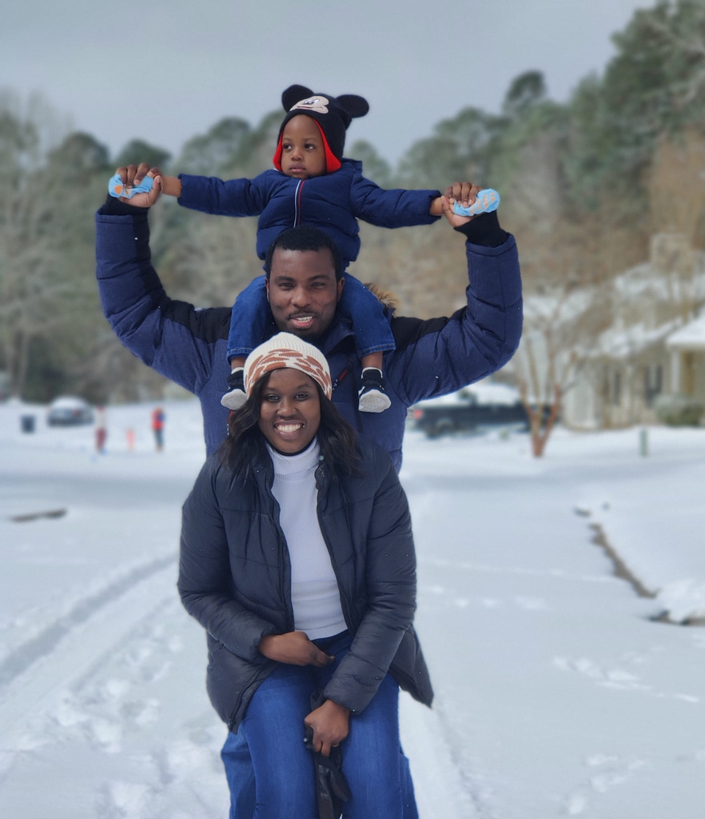

- Christian
- Ivorian / Cameroonian
- Husband and father
- Economics professor at Louisiana Tech University
- Data Science trainer
- Data Science and Economics consultant

# Enough about me!

It’s time to talk about you!

# Congratulations!

- You have just been designated as the country’s Minister for Health.

# This is very exciting, but…

You are now facing two main challenges:

- You are inexperienced
- A global pandemic just broke out!

# The future of the nation is in your hands!

# Strategy Board

1. Make an assessment of the “state of things”
- Where are all the health sites in the country?
- Do we have enough “appropriate” health sites for storing and handling the cure?
- Which health districts do not have “appropriate” health sites?

# Strategy Board

2. Capacity building (upgrade health sites)
- Find the most ideal location in each health district
- Identify the health site which is closest to the location
- Are all “appropriate” health sites optimally located?
- Which health districts are completely okay (do not need intervention)?

# Strategy Board

3. Risk assessments
- Which health districts have the highest population *densities*?
- Which health districts should we prioritize?

# Not considered today

- Build or upgrade facilities? (which option is cost effective and least time consuming?)
- Optimal dispatch of the cure throughout the country using road network data
- The centroid method may not always be the best choice
- Some health districts may be so small that buidling/upgrading a health facility may not be ideal
- Many “appropriate” health sites are clustered so it may not be optimal to supply all of them with the cure due to its limited supply

# Want to do the same for your country?

- Country + admin shapefiles: [The Humanitarian Data Exchange](https://data.humdata.org/)
- Heath sites point locations: The `{afrihealthsites}` package, which pulls data from [healthsites.io](https://www.healthsites.io/)
- Road network data: [WFPGeoNode](https://geonode.wfp.org/)